# Discussion12

Teryl Schmidt

12/4/2018

Consider the experiment where we are interested in determining the dose-response rates between several antibiotics applied at the same concentration. Treatments are randomly applied to cultured bacteria, and the percent reductions in bacterial population are given:

```
Trt 1: 13.3 13.7 11.6 11.9 12.0 12.9 12.3 12.1 12.3 12.3
Trt 2: 12.5 13.9 12.4 14.0 12.8
Trt 3: 16.8 16.6 17.1 14.6 17.4 16.5
Trt 4: 13.2 14.2 13.5 13.2 14.3 12.7 14.9 13.3 13.5
```

1. Analyze the data graphically. Does it look like ANOVA will be useful?

```r
Trt1 = c(13.3, 13.7, 11.6, 11.9, 12.0, 12.9, 12.3, 12.1, 12.3, 12.3)
Trt2 = c(12.5, 13.9, 12.4, 14.0, 12.8)
Trt3 = c(16.8, 16.6, 17.1, 14.6, 17.4, 16.5)
Trt4 = c(13.2, 14.2, 13.5, 13.2, 14.3, 12.7, 14.9, 13.3, 13.5)
```

2. Create an Anova table, and decide whether we have sufficient evidence to reject the null. (Work out calculations in R and/or on calculator so you get practice.)

[output not shown]

3. Conduct multiple comparisons for each treatment using 95% CI based on Tukey-Kramer by hand, then verify with R function. Make a table to summarize your findings.

1 & 2 Q = 3.87964 y¯<sub>1</sub> = 12.44 y¯<sub>2</sub> = 13.12 n<sub>1</sub> = 10 n<sub>2</sub> = 5

y¯<sub>1</sub> - y¯<sub>2</sub> +- Q / sqrt(2) * sqrt(MSE * (1 / n<sub>1</sub> + 1 / n<sub>2</sub>)) 12.44 -13.12 +- 3.87964 / sqrt(2) * sqrt(0.574 * (1 / 10 + 1 / 5)) (0.4583951, -1.818395) * Contain 0

1 & 3 * No 0

1 & 4 * No 0

2 & 3 * No 0

2 & 4 * Contains 0

3 & 4 * No 0

Order from smallest to largest mean

```
Trt | Mean  | Group
1   | 12.44 |   A
2   | 13.12 |   A B
4   | 13.64 |     B
3   | 16.5  |       C
```

4. Perform a Kruskal - Wallis test with possible Wilconon Rank Sum posthoc comparison (with Bonferoni correction). Summarize these findings in a table. Are the conclusions consistent between the two methods? Explain why.
2. We measure the heights and weights of 4 randomly chosen students. The value and some summary measures are given below. You can also use the fact that ∑<sub>i=1</sub> (x − x ̄)(y − y ̄) = 680

```
Student   |   x: wts (kg)  |   y: hts (cm)
  1       |       50       |      151
  2       |       60       |      165
  3       |       70       |      178
  4       |       80       |      192


Variable    |   Mean    |   Standard Deviation
Weight (x)  |   65      |           12.91
Height(y)   |   171.5   |           17.56
```

For all of the parts below (except for graphs), please perform the calculations by hand, and show your work. You may use R to check your answers.

```r
Studentweight = c(50, 60, 70, 80) # y
Studentheight = c(151, 165, 178, 192) #x
```

1. Based on the scatter plot, does a straight-line model seem reasonable? If so, compute compute the sample correlation and the least square estimates for the y intercept and slope of the regression line relating height (y) to weight (x).

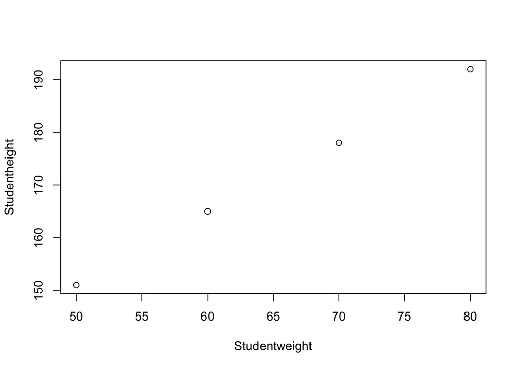

```r
plot(Studentweight, Studentheight)
```

2. Compute the 4 residuals and create a plot of the residuals vs fitted values (by hand and R) and a QQ plot of the residuals (just in R). Do the necessary regression assumptions seem met?
3. Compute the MSError from the residuals calculated above.
4. Perform a test of H0 :β1 =1 vs H1 :β1 = ̸=1, using a t-test at α = 0.05. Make a conclusion in the context of the problem.
5. If a student weight is 75kg, what does the model predict to be the height? Compute the estimated SE of this estimate assuming it is for a single future value and 95% prediction interval.

6. What is the estimated height of a student with weight 75kg? Compute the estimated SE of this estimate and find 95% CI.